# Classification of news headlines with impact on the probability of stock prices changes

Max Franke

April 28, 2020

Course: CIS-627 CAPSTONE

Term: Spring/T2

# Capstone Project

## Approach

In this analysis, the following approach will be used:

### 0. Workspace preparation

- This section will clean the workspace, load the libraries, the datasets and prepare the datasets

### 1. Headline Tags

- The analysis starts with two datasets: Healines from 2019/2020 (1) and the Close stock prices from Apple (2) - Note: Later on, this approach will be rolled out for all companies in the [Dow Jones Industrial Average](https://money.cnn.com/data/dow30/)

#### Process

1. Subset the news (headline and description) for the stock symbol (e.g. “Apple”, and “AAPL”; transformation in lowercases)
2. Iterate through each headline of the subset and count the words, result: table of the most frequently mentioned tags (e.g. update)
3. Create a result dataframe: Symbol, Counts, Tag, Price Difference from minute 1 to minute 15

(3a) For each tag, the price difference from 1-15min will be calculated and to the result dataframe attanded

(3b) Check if there is a statistical difference between the time frames

### 2. Comparison of price differences

1. Most profitable time frame
2. Most profitable tag

### 3. Creating input data

Predictors (x) = current close price, Volume, avg. top three tag price difference

| Variable | Example value |
| --- | --- |
| Current close price | 157.54 |
| Volume | 172 |
| FirstTag | 28.809 |
| SecondTag | 24.496 |
| ThirdTag | 23.273 |

Outcome (y) = Price difference for 3 min concerning the headline

### 5. Model Evaluation

- Check the model performance: Accuracy, error minmizing etc.

## Workspace preparation

### Approach

In this section the workspace will be prepared. This means that first the global environment will be cleaned, and all required packages will be loaded.

### Clean Workspace

```r
rm(list = ls())
```

### Install libraries

```r
## Install packages
my_packages <- c("plotly", "tidyverse", "reshape", "keras", "tm", "SnowballC", "sjmisc")
#install.packages(my_packages, repos = "http://cran.rstudio.com")
```

### Load packages

```r
library(tidyverse)
library(plotly)
library(reshape)
#library(keras)
library(lubridate)
library(tm)
library(SnowballC)
library(sjmisc)
```

### Load news Dataset

```r
## Load data of stocks with headlines and description
setwd("/Users/MaxFranke/Desktop/05_Big Data Analytics/04_Classes/04 SP:Term2/CIS-627 CAPSTONE/News-Classification/02_Data/04_NewData")
news <- read.csv("Stock Text Symbol - 2019-2020.csv")
```

### Transform data

```r
# Names of dataframe
names(news) <- c("Date", "headline", "description")
news$Date <- strptime(as.character(news$Date), format = "%m/%d/%Y %H:%M") + 5*60 - 5*60
knitr::kable(head(news, 3), format = "markdown")
```

| Date | headline | description |
| --- | --- | --- |
| 0019-01-20 15:21:00 | JD(U) to vote against citizenship bill in Rajya Sabha |  |
| 0019-01-20 15:21:00 | Gillibrand: Previous immigration stances weren’t ‘empathetic,’ ‘kind’ | Democratic Sen. Kirsten Gillibrand said Sunday that her previous controversial stances on immigration “certainly weren’t empathetic and they were not kind.” |
| 0019-01-20 15:21:00 | Pak name new-look team for Pro-League Hockey, drop 11 players from WC side | Pakistan selectors on Sunday effected a wholesale change in the country’s hockey squad for the FIH Pro-League series beginning next month by dropping 11 players, including captain Muhammad Rizwan, who… |

### Load APPL dataset

```r
setwd("/Users/MaxFranke/Desktop/05_Big Data Analytics/04_Classes/04 SP:Term2/CIS-627 CAPSTONE/News-Classification/02_Data/04_NewData")
apple <- read.csv("AAPL.USUSD_Candlestick_1_M_ASK_01.01.2019-23.04.2020.csv")
```

### Transform data

```r
apple$Local.time <- strptime(apple$Local.time, format = "%d.%m.%Y %H:%M")
rownames(apple) <- NULL
apple <- apple[,c(1,5,6)]
names(apple) <- c("Date", "Close", "Volume")
apple$Date <- apple$Date + 5*60 - 5*60
knitr::kable(head(apple, 3), format = "markdown")
```

| Date | Close | Volume |
| --- | --- | --- |
| 2019-01-02 09:30:00 | 154.842 | 908974 |
| 2019-01-02 09:31:00 | 155.203 | 952697 |
| 2019-01-02 09:32:00 | 154.853 | 1042134 |

## Headline Tags

```r
news$headline <- str_replace_all(news$headline, "[[:punct:]]", " ")
news$description <- str_replace_all(news$description, "[[:punct:]]", " ")
# Check if Apple or AAPL exists in headline
text_Apple_headline <- str_detect(tolower(news$headline), c("apple", "aapl"))
# Check if Apple or AAPL exists in description
text_Apple_description <- str_detect(tolower(news$description), c("apple", "aapl"))
# Summarise in one dataset
text_Apple_merge <- data.frame(headline = text_Apple_headline, description = text_Apple_description)
# Get the rows where Apple or AAPL exists
text_Apple_result <- which(text_Apple_merge[,1] == TRUE | text_Apple_merge[,2] == TRUE)

Apple <- news[text_Apple_headline,]

knitr::kable(head(Apple, 3), caption = paste("Identified news: ", nrow(Apple)), format = "markdown")
```

|  | Date | headline | description |
| --- | --- | --- | --- |
| 103 | 0019-01-06 07:37:00 | Amazon Kicks Off Apple Sale With Discounts On 2018 MacBook Air iPhone X and More | Amazon sale also has discounts on iPhone 6S iPhone 6 as well as offers on iPhone XS iPhone XS Max iPhone 8 iPhone 8 Plus and other iPhone models |
| 425 | 0019-01-12 04:16:00 | Qualcomm Says Apple Violating Chinese Court Order Despite iOS 12 1 2 Update | Qualcomm said it believes Apple remains in violation of a Chinese court s orders to stop selling iPhones despite the iOS 12 1 2 software update that Apple pushed on Monday |
| 849 | 0019-01-12 03:52:00 | More Companies Are Bypassing Big App Stores Costing Apple Google Millions | A growing number of software companies are looking to bypass the dominant app store gatekeepers at Apple and Google |

### Iterate through each headline and count the words

#### Step 1: Extract and then load the headlines from dataset

First, the column “headline” is extracted and saved to a txt.file. Then, this txt. file is load into R.

The following table shows the first 3 titles of this file:

| headline |
| --- |
| “Amazon Kicks Off Apple Sale With Discounts On 2018 MacBook Air iPhone X and More” |
| “Apple s squid emoji has been anatomically incorrect for years Monterey Bay Aquarium points out” |
| “Apple Watch Series 4 Gets ECG and New Infograph Complications With watchOS 5 1 2” |

#### Step 2: Text mining

1. Load the txt. file as a corpus

```r
# Load the data as a corpus
docs <- Corpus(VectorSource(text))
```

3. Text transformation
- Replace special characters from text

```r
toSpace <- content_transformer(function (x , pattern ) gsub(pattern, " ", x))
docs <- tm_map(docs, toSpace, "/")
docs <- tm_map(docs, toSpace, "@")
docs <- tm_map(docs, toSpace, "\\|")
```

4. Cleaning the text
- Convert the text to lower case
- Remove punctuations
- Eliminate extra white spaces
- Remove english common stopwords
- Remove the name of the stocks

```r
# Convert the text to lower case
docs <- tm_map(docs, content_transformer(tolower))
# Remove punctuations
docs <- tm_map(docs, removePunctuation)
# Eliminate extra white spaces
docs <- tm_map(docs, stripWhitespace)
# Remove english common stopwords
docs <- tm_map(docs, removeWords, stopwords("english"))
# Remove the name of the stocks
docs <- tm_map(docs, removeWords, c("apple", "apples"))
```

#### Step 3: Building a term-document matrix

A term-document matris is a table which contains the frequency of the words.

In the following table, the first 20 words of this term-document matrix are shown.

```r
dtm <- TermDocumentMatrix(docs)
dtm_matrix <- as.matrix(dtm)
dtm_vector <- sort(rowSums(dtm_matrix),decreasing=TRUE)
dtm_dataframe <- data.frame(word = names(dtm_vector),freq=dtm_vector)
rownames(dtm_dataframe) <- NULL
knitr::kable(head(dtm_dataframe, 20), format = "html")
```

| word | freq |
| --- | --- |
| update | 162 |
| iphone | 140 |
| china | 108 |
| says | 107 |
| new | 104 |
| stocks | 86 |
| qualcomm | 65 |
| tech | 44 |
| wall | 43 |
| iphones | 40 |
| global | 39 |
| will | 38 |
| sales | 37 |
| india | 37 |
| app | 36 |
| cook | 36 |
| ceo | 35 |
| shares | 34 |
| amazon | 33 |
| news | 32 |

#### Create result dataframe

```r
Apple_Result <- data.frame(Symbol = "AAPL",
                           Counts = dtm_dataframe$freq,
                           Tag = dtm_dataframe$word)
Apple_Result[, c("1","2","3","4","5","6","7","8","9","10","11","12","13","14","15")] <- NA
names(Apple_Result) <- c("Symobl", "Counts", "Tag", paste0("PD", seq(1:15)))
for (i in 4:18) {
  Apple_Result[,i] <- as.numeric(Apple_Result[,i])
}

knitr::kable(head(Apple_Result, 5), format = "markdown")
```

| Symobl | Counts | Tag | PD1 | PD2 | PD3 | PD4 | PD5 | PD6 | PD7 | PD8 | PD9 | PD10 | PD11 | PD12 | PD13 | PD14 | PD15 |
| --- | --- | --- | --- | --- | --- | --- | --- | --- | --- | --- | --- | --- | --- | --- | --- | --- | --- |
| AAPL | 162 | update | NA | NA | NA | NA | NA | NA | NA | NA | NA | NA | NA | NA | NA | NA | NA |
| AAPL | 140 | iphone | NA | NA | NA | NA | NA | NA | NA | NA | NA | NA | NA | NA | NA | NA | NA |
| AAPL | 108 | china | NA | NA | NA | NA | NA | NA | NA | NA | NA | NA | NA | NA | NA | NA | NA |
| AAPL | 107 | says | NA | NA | NA | NA | NA | NA | NA | NA | NA | NA | NA | NA | NA | NA | NA |
| AAPL | 104 | new | NA | NA | NA | NA | NA | NA | NA | NA | NA | NA | NA | NA | NA | NA | NA |

#### ITERATION

For each tag, the price difference from 1-15min will be calculated and to the result dataframe attanded

```r
# Remove the word apple to avoid that the tag "app" will be found in "apple"
Apple$headline <- str_remove(tolower(Apple$headline),"apple")

for (i in 1:nrow(dtm_dataframe)) {
  # Get all rows from apple, where we can find the word i (but just exlude the timeframe between 4 pm and 9 am because the market is closed)
  Apple_table <- subset(Apple, lubridate::hour(Date) < 16 &
                          lubridate::hour(Date) > 9)[str_detect(tolower(as.character(Apple$headline)), as.character(dtm_dataframe[i,1])),]
  # Merge the datasets
  result <- merge(Apple_table, apple, by = "Date", sort = FALSE, all.x = TRUE)
  # If the merge shows 0 rows or the close price was not found then don't calculate anything
  if (nrow(result) == 0 || is.na(result$Close) == FALSE) {
  # Attand the price difference from minute 1 to minute 15 to the dataframe Apple_Result
    for (min in 1:15) {
      minute <- result$Date + min*60
      result$PriceDifference <- result$Close - apple[which(apple$Date %in% minute),2]
      sumPD <- mean(result$PriceDifference, na.rm = TRUE)
      Apple_Result[i,3+min] <- sumPD
    }
  }
}

# Replace all NA and NAN with 0
for (i in 1:ncol(Apple_Result)) {
 Apple_Result[,i][is.nan(Apple_Result[,i])]<-0
 Apple_Result[,i][is.na(Apple_Result[,i])]<-0
}

knitr::kable(head(Apple_Result, 10), format = "markdown")
```

| Symobl | Counts | Tag | PD1 | PD2 | PD3 | PD4 | PD5 | PD6 | PD7 | PD8 | PD9 | PD10 | PD11 | PD12 | PD13 | PD14 | PD15 |
| --- | --- | --- | --- | --- | --- | --- | --- | --- | --- | --- | --- | --- | --- | --- | --- | --- | --- |
| AAPL | 162 | update | 0.0131667 | 0.0445000 | 0.0675000 | 0.0657500 | 0.0608750 | 0.0336667 | 0.0589167 | 0.0622500 | 0.0517083 | 0.0811250 | 0.0585417 | 0.0167917 | 0.0174167 | 0.0135000 | -0.0098750 |
| AAPL | 140 | iphone | 2.0620000 | 2.0689855 | 2.0822319 | 2.0805507 | 2.0864203 | 2.0734638 | 2.0949855 | 2.0854203 | 2.0874638 | 2.0691014 | 2.0605652 | 2.0407246 | 2.0457536 | 2.0574058 | 2.0691739 |
| AAPL | 108 | china | -0.0026842 | 0.0215000 | 0.0072368 | 0.0025789 | -0.0157105 | -0.0333947 | -0.0532368 | -0.0626842 | -0.0631053 | -0.0364737 | -0.0514211 | -0.0391842 | -0.0431316 | -0.0757895 | -0.0696053 |
| AAPL | 107 | says | 4.0120870 | 3.9757826 | 3.9817391 | 3.9336087 | 3.9513478 | 3.9782609 | 4.0114783 | 4.0110000 | 4.0231739 | 4.0003043 | 4.0048696 | 4.0020000 | 3.9976522 | 3.9652174 | 3.9393478 |
| AAPL | 104 | new | 0.0045172 | -0.0300345 | -0.0167241 | 0.0179310 | -0.0160345 | -0.0043793 | -0.0157586 | -0.0516207 | -0.0668621 | -0.0673793 | -0.0610000 | -0.0937931 | -0.0870000 | -0.0821724 | -0.0638621 |
| AAPL | 86 | stocks | 0.6555217 | 0.6548696 | 0.6780435 | 0.7118261 | 0.6243043 | 0.6248261 | 0.6195652 | 0.6412609 | 0.7330870 | 0.7554348 | 0.7192609 | 0.6610435 | 0.6379130 | 0.6455652 | 0.6915652 |
| AAPL | 65 | qualcomm | 0.7961111 | 0.8311667 | 0.8766667 | 0.8852778 | 0.8607222 | 0.8238889 | 0.8983333 | 0.8787778 | 0.8521667 | 0.8678889 | 0.8707222 | 0.8326667 | 0.8151111 | 0.8033333 | 0.8079444 |
| AAPL | 44 | tech | -0.0298182 | -0.0173636 | -0.0048182 | -0.0128182 | -0.0287273 | 0.0148182 | 0.0235455 | -0.0212727 | -0.0901818 | -0.0956364 | -0.1260000 | -0.1494545 | -0.1653636 | -0.1746364 | -0.2329091 |
| AAPL | 43 | wall | -0.9852667 | -0.9338000 | -0.9640667 | -0.9932000 | -1.0422000 | -1.0292667 | -1.0380000 | -1.0074000 | -0.9526667 | -0.9791333 | -0.9840667 | -1.0314000 | -1.0130000 | -1.0412000 | -0.9694667 |
| AAPL | 40 | iphones | 3.4951000 | 3.4748000 | 3.4928000 | 3.5169000 | 3.5416000 | 3.5750000 | 3.5963000 | 3.5580000 | 3.5734000 | 3.5971000 | 3.5802000 | 3.5125000 | 3.4890000 | 3.5647000 | 3.5771000 |

Note: If a headline was posted after 4 pm and before 9 am, it is not relevant for this analysis. Because there can not be price difference in a range aobut 15 min because the stock price doesn’t change between 4 pm and 9:30 am in the morning.

#### Statistical difference between the minutes

```r
anova_df <- melt(Apple_Result, id = c("Symobl", "Counts", "Tag"))

aov <- aov(value ~ variable, data = anova_df)
summary(aov)
```

```
##                Df Sum Sq Mean Sq F value Pr(>F)
## variable       14      7  0.4811   1.881 0.0235 *
## Residuals   43890  11225  0.2558
## ---
## Signif. codes:  0 '***' 0.001 '**' 0.01 '*' 0.05 '.' 0.1 ' ' 1
```

```r
min(TukeyHSD(aov)$variable[,4])
```

```
## [1] 0.3064553
```

## Tags and Price Differences

#### Most profitable time frame

```r
PD_comparison <- anova_df %>%
          drop_na %>%
          dplyr::group_by(variable) %>%
          dplyr::summarize(AvgPriceDifferences = mean(value))

knitr::kable(head(PD_comparison[order(PD_comparison$AvgPriceDifferences, decreasing = TRUE),], 15), format = "markdown")
```

| variable | AvgPriceDifferences |
| --- | --- |
| PD3 | 0.0660973 |
| PD2 | 0.0635690 |
| PD4 | 0.0610843 |
| PD5 | 0.0597068 |
| PD1 | 0.0590243 |
| PD7 | 0.0563134 |
| PD6 | 0.0517921 |
| PD9 | 0.0508042 |
| PD8 | 0.0505410 |
| PD10 | 0.0478283 |
| PD11 | 0.0405444 |
| PD15 | 0.0317939 |
| PD13 | 0.0311639 |
| PD14 | 0.0306111 |
| PD12 | 0.0304444 |

#### Most profitable tag

```r
profitable_word <- Apple_Result %>%
                      drop_na() %>%
                      dplyr::group_by(Counts, Tag) %>%
                      summarize(AvgPriceDiffernces = (PD1+PD2+PD3+PD4+PD5+PD6+PD7+PD8+PD9+PD10+PD11+PD12+PD13+PD14+PD15)/15)

knitr::kable(head(profitable_word[order(profitable_word$AvgPriceDiffernces, decreasing = TRUE),], 15), format = "markdown")
```

| Counts | Tag | AvgPriceDiffernces |
| --- | --- | --- |
| 12 | get | 9.296104 |
| 1 | emi | 6.530567 |
| 9 | selling | 6.521507 |
| 5 | hire | 5.627695 |
| 3 | sell | 5.536878 |
| 9 | plans | 5.486767 |
| 4 | misses | 5.240833 |
| 5 | slump | 5.202567 |
| 1 | red | 5.053924 |
| 24 | foxconn | 4.664815 |
| 4 | miss | 4.458429 |
| 1 | onn | 4.196440 |
| 107 | says | 3.985858 |
| 9 | reports | 3.901425 |
| 17 | hit | 3.851213 |

### Comparison of Time Frames concerning Price Differences

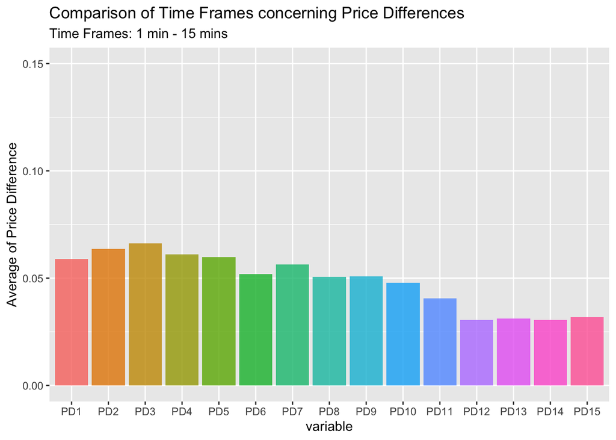

```r
ggplot(data = PD_comparison, mapping = aes(x = variable, y = AvgPriceDifferences, fill = variable)) +
  geom_col(alpha = .8) +
  guides(fill = FALSE) +
  scale_y_continuous(limits = c(0,0.15)) +
  labs(title = "Comparison of Time Frames concerning Price Differences",
       subtitle = "Time Frames: 1 min - 15 mins",
       y = "Average of Price Difference")
```

### Comparison of tags

[figure not shown]

```r
ggplot(data = head(profitable_word[order(profitable_word$AvgPriceDiffernces, decreasing = TRUE),], 15),
       mapping = aes(x = reorder(Tag, AvgPriceDiffernces), y = AvgPriceDiffernces, fill = Tag)) +
  geom_col(alpha = .8) +
  theme(axis.text.x = element_text(angle = 45, hjust = 1)) +
  guides(fill = FALSE) +
  labs(title = "Comparison of Tags concerning Price Differences",
       y = "Average of Price Difference",
       x = NULL)
```

## Creating input data

### Min Max Transformation (all features will have the exact same scale but does not handle outliers well)

```r
minMax <- function(x) {
  return ((x - min(x)) / (max(x) - min(x)))
}
```

### Z-Score (Handles outliers, but does not produce normalized data with the exact same scale)

```r
zScore <- function(x){
  return(scale(x))
}
```

### Weighted and normalized Price Difference for the tags

```r
# Weighted Tags
weightedTags <- data.frame(Tag = Apple_Result$Tag,
                           PriceDiff = NA)

# Normalize with zScore the Price Difference for 3 minutes
Price_Difference_3min_norm <- zScore(Apple_Result$PD3)
# Normalize with ZScore the Counts
Counts_norm <- zScore(Apple_Result$Counts)

# Weighted mean
#weightedTags$PriceDiff <- weighted.mean(Price_Difference_3min_norm, Counts_norm)

# Get the weighted mean for every Tag for the time frame 3 min
for (i in 1:nrow(Apple_Result)) {
  weightedTags[i,2] <- weighted.mean(Price_Difference_3min_norm[i], Counts_norm[i])
}

# Define TAGS
TAGS <- data.frame(Tag = weightedTags$Tag,
                   WeightedNormalizedPD <- weightedTags$PriceDiff)
names(TAGS) <- c("Tag", "WeightedNormalizedPD")

# Replace all NAN with 0
TAGS$WeightedNormalizedPD[is.na(TAGS$WeightedNormalizedPD)] <- 0
TAGS$WeightedNormalizedPD[is.nan(TAGS$WeightedNormalizedPD)] <- 0

knitr::kable(head(TAGS, 15), format = "markdown")
```

| Tag | WeightedNormalizedPD |
| --- | --- |
| update | 0.0029059 |
| iphone | 4.1769076 |
| china | -0.1219437 |
| says | 8.1121937 |
| new | -0.1715846 |
| stocks | 1.2677936 |
| qualcomm | 1.6792893 |
| tech | -0.1469186 |
| wall | -2.1342325 |
| iphones | 7.0992387 |
| global | -0.1598737 |
| will | -0.2648665 |
| sales | -0.1298926 |
| india | -0.1062748 |
| app | -0.0734895 |

### Top three Tag for each headline (result is a dataframe with weighted and normalized price difference for the top three tags for each headline)

```r
optimalTags <- data.frame(matrix(nrow = 0, ncol = 3))
names(optimalTags) <- c("Tag1", "Tag2", "Tag3")

for (i in 1:nrow(Apple)) {
  # Get the sentence from headline
  sentence <- word(Apple[i,2], 1, sapply(strsplit(Apple[i,2], " "), length))
  # Get the three best Tags for this headline as a weighted and normalized mean
  topThreeTags <- head(TAGS[str_detect(tolower(sentence), as.character(TAGS[,1])),2],3)
  # Save these three values
  result <- data.frame(Tag1 = topThreeTags[1],
                       Tag2 = topThreeTags[2],
                       Tag3 = topThreeTags[3])
  optimalTags <- rbind(optimalTags, result)
}
knitr::kable(head(optimalTags, 15), format = "markdown")
```

| Tag1 | Tag2 | Tag3 |
| --- | --- | --- |
| 4.1769076 | 5.9976465 | 0.0657174 |
| -0.2477747 | -0.3530881 | -0.2829942 |
| -0.1715846 | 0.0549584 | -0.2472567 |
| -0.1236900 | 19.2338373 | -0.1462594 |
| 0.0029059 | -0.1320531 | -0.0235827 |
| -0.1441876 | -0.0447441 | 11.5497517 |
| -0.1407347 | 0.1758963 | -0.0136680 |
| 0.0029059 | 8.1121937 | 1.6792893 |
| 4.1769076 | -0.1715846 | 2.8593527 |
| -0.1219437 | -0.1481009 | 6.0996930 |
| 4.1769076 | 7.0992387 | -0.1576539 |
| 0.0029059 | -0.4170359 | -0.1003986 |
| -0.1715846 | -0.1469186 | 5.9976465 |
| -0.0734895 | -0.3765679 | -0.0731269 |
| -0.1715846 | 5.9577474 | -0.0229908 |

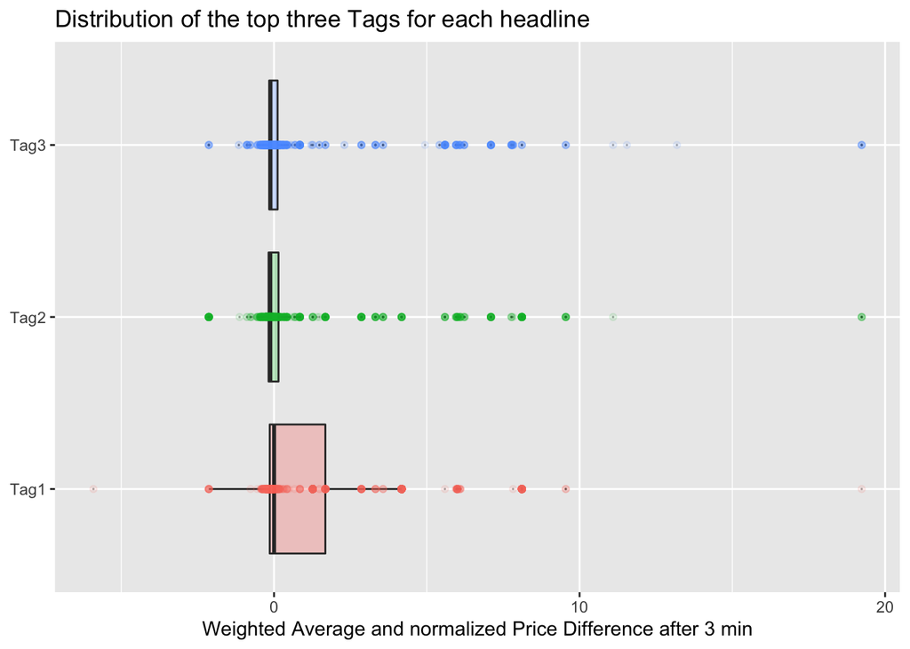

```r
optimalTags_graph <- optimalTags
optimalTags_graph$ID <- "ID"
optimalTags_graph <- melt(optimalTags_graph, id = "ID")
ggplot(data = optimalTags_graph, mapping = aes(x = value, y = variable)) +
  geom_boxplot(mapping = aes(fill = variable), alpha = 0.3, outlier.size = 0) +
  geom_point(mapping = aes(color = variable), alpha = 0.1) +
  guides(fill = FALSE, color = FALSE) +
  labs(title = "Distribution of the top three Tags for each headline",
       x = "Weighted Average and normalized Price Difference after 3 min",
       y = NULL)
```

### Get the volume, close price, and price difference for 3 min for each headline

```r
# Close Price and Volume
CP_volume_PD <- merge(Apple, apple, by = "Date", sort = FALSE, all.x = TRUE)
# Price Difference
Apple_3min <- Apple
Apple_3min$Date <- Apple_3min$Date + 3*60
Apple_3min <- merge(Apple_3min, apple, by = "Date", sort = FALSE, all.x = TRUE)
CP_volume_PD$PD <- (CP_volume_PD$Close - Apple_3min$Close) / CP_volume_PD$Close
CP_volume_PD$PD <- zScore(CP_volume_PD$PD)

knitr::kable(head(CP_volume_PD, 3), format = "html")
```

| Date | headline | description | Close | Volume | PD |
| --- | --- | --- | --- | --- | --- |
| 2019-01-14 09:46:00 | s services revenue growth is slowing down rbc says | RBC Capital Markets estimates Apple s services revenue has slowed to 18 percent year over year growth in the December quarter | 150.163 | 822766 | 0.5675633 |
| 2019-01-14 10:45:00 | venezuela s maduro to announce economic measures as new term starts | Venezuelan President Nicolas Maduro was set to announce new economic measures on Monday after starting a disputed second term in office last week although economists expect few major changes as the co… | 150.432 | 771423 | 1.7562590 |
| 2019-01-16 10:45:00 | digital lettering techniques from christmas campaign illustrator rachel joy price | Tips on how to create letters using discovered type and how to add depth to your letters using the iPad | 154.642 | 773125 | -0.8340913 |

### Input:

Current close price, current volume, Price difference for 3 mins, weighted average and normalized price difference for the top three tags for each headline

```r
INPUT <- cbind(CP_volume_PD[,c(4,5,6)], optimalTags)
# Drop all NA's
INPUT <- INPUT %>% drop_na()
knitr::kable(head(INPUT, 3), format = "html")
```

| Close | Volume | PD | Tag1 | Tag2 | Tag3 |
| --- | --- | --- | --- | --- | --- |
| 150.163 | 822766 | 0.5675633 | 4.1769076 | 5.9976465 | 0.0657174 |
| 150.432 | 771423 | 1.7562590 | -0.2477747 | -0.3530881 | -0.2829942 |
| 154.642 | 773125 | -0.8340913 | -0.1715846 | 0.0549584 | -0.2472567 |

### Correlation

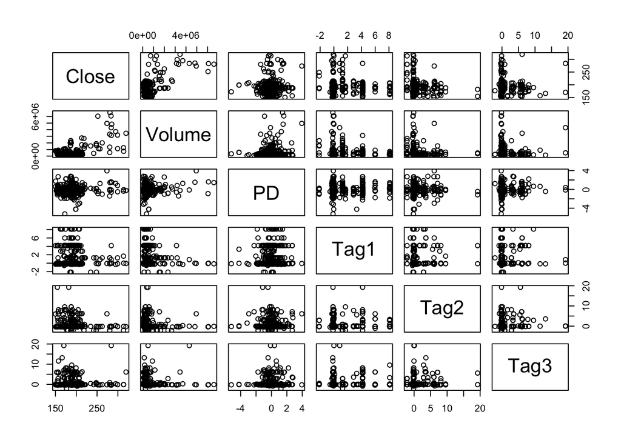

```r
pairs(INPUT)
```

### Export as csv file

```r
write_csv(x = INPUT, path = "Input.csv", col_names = TRUE)
```

## Model Building

Load H2o

[output not shown]

[output not shown]

Load data

```r
Input <- h2o.importFile(path = normalizePath("/Users/MaxFranke/Desktop/05_Big Data Analytics/04_Classes/04 SP:Term2/CIS-627 CAPSTONE/News-Classification/03_Code/02_News/Input.csv"))
```

Splitting

```r
# split samples
splits <- h2o.splitFrame(Input, c(0.6,0.2), seed=1234)
train  <- h2o.assign(splits[[1]], "train.hex") # 60%
valid  <- h2o.assign(splits[[2]], "valid.hex") # 20%
test   <- h2o.assign(splits[[3]], "test.hex")  # 20%
```

Define predictors and response

```r
response <- "PD"
predictors <- setdiff(names(Input), response)
predictors
```

```
## [1] "Close"  "Volume" "Tag1"   "Tag2"   "Tag3"
```

Appraoch: Reduce the MSE by changegin the layer permutation and the epochs

```r
'layers <- expand.grid(rep(list(c(5, 10, 20, 40, 80)), 3))
Result_layers <- expand.grid(rep(list(c(5, 10, 20, 40, 80)), 3))
names(Result_layers) <- c("Hidden1", "Hidden2", "Hidden3")
Result_layers$MSE_10ep <- NA
Result_layers$MSE_100ep <- NA
Result_layers$MSE_1000ep <- NA
Result_layers$MSE_10000ep <- NA

# For every layer combination
for (i in 193:nrow(layers)) {
  # and for the different epochs
  for (epochs in c(10,100,1000, 10000)) {
# Create the model
h2oDL <- h2o.deeplearning(x = predictors,
                          y = response,
                          training_frame = train,
                          hidden = c(layers[i,1], layers[i,2]),
                          epochs = epochs,
                          seed = 12345,
                          validation_frame = valid)
    # Append the MSE to the result dataframe
    if (epochs == 10) {
        Result_layers[i,4] <- h2o.mse(object = h2oDL)
    } else if (epochs == 100) {
      Result_layers[i,5] <- h2o.mse(object = h2oDL)
    } else if (epochs == 1000) {
      Result_layers[i,6] <- h2o.mse(object = h2oDL)
    } else {
      Result_layers[i,7] <- h2o.mse(object = h2oDL)
    }
  }
write.csv(Result_layers, file = "Result_layers.csv")
}'
```

[output not shown]

Import csv file

```r
Result_layers <- read.csv("/Users/MaxFranke/Desktop/05_Big Data Analytics/04_Classes/04 SP:Term2/CIS-627 CAPSTONE/News-Classification/03_Code/02_News/Result_layers.csv")
knitr::kable(head(Result_layers, 3), format = "markdown")
```

| Hidden1 | Hidden2 | Hidden3 | MSE_10ep | MSE_100ep | MSE_1000ep | MSE_10000ep |
| --- | --- | --- | --- | --- | --- | --- |
| 5 | 5 | 5 | 0.8402438 | 0.8045304 | 0.6398926 | 0.9240361 |
| 10 | 5 | 5 | 0.8352420 | 0.8739856 | 0.8830124 | 0.8349964 |
| 20 | 5 | 5 | 0.8084639 | 0.7705929 | 0.8176647 | 0.8176650 |

Prove statistically if there is a significant difference between the epochs

```r
epochs_results <- melt(Result_layers, id = c("Hidden1", "Hidden2", "Hidden3"))

aov <- aov(value ~ variable, data = epochs_results)
summary(aov)
```

```
##              Df Sum Sq Mean Sq F value Pr(>F)
## variable      3  0.033 0.01111   0.668  0.572
## Residuals   496  8.251 0.01664
```

```r
TukeyHSD(aov)
```

```
##   Tukey multiple comparisons of means
##     95% family-wise confidence level
##
## Fit: aov(formula = value ~ variable, data = epochs_results)
##
## $variable
##                                diff         lwr        upr     p adj
## MSE_100ep-MSE_10ep     -0.016952594 -0.05900693 0.02510174 0.7265145
## MSE_1000ep-MSE_10ep     0.003114283 -0.03894005 0.04516862 0.9975319
## MSE_10000ep-MSE_10ep    0.002046351 -0.04000798 0.04410069 0.9992943
## MSE_1000ep-MSE_100ep    0.020066877 -0.02198746 0.06212121 0.6080317
## MSE_10000ep-MSE_100ep   0.018998946 -0.02305539 0.06105328 0.6495223
## MSE_10000ep-MSE_1000ep -0.001067931 -0.04312227 0.04098640 0.9998993
```

MSE

```r
# Min MSE
subset(epochs_results, value == min(epochs_results$value))
```

```
##     Hidden1 Hidden2 Hidden3    variable      value
## 425      80      80      10 MSE_10000ep 0.03937635
```

```r
# Top 10 Min MSE
#write.csv(head(epochs_results[order(epochs_results$value, decreasing = FALSE),], 10), "topTen.csv")
```

Average

```r
knitr::kable(epochs_results %>%
  group_by(variable) %>%
  summarize(AvgMSE = mean(value)), format = "markdown")
```

| variable | AvgMSE |
| --- | --- |
| MSE_10ep | 0.8274176 |
| MSE_100ep | 0.8104650 |
| MSE_1000ep | 0.8305319 |
| MSE_10000ep | 0.8294640 |

Distribution

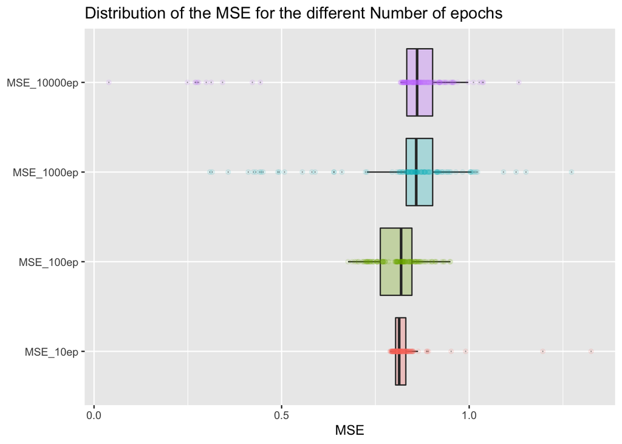

```r
ggplot(data = epochs_results, mapping = aes(x = value, y = variable)) +
  geom_boxplot(mapping = aes(fill = variable), alpha = 0.3, outlier.size = 0) +
  geom_point(mapping = aes(color = variable), alpha = 0.1) +
  guides(fill = FALSE, color = FALSE) +
  labs(title = "Distribution of the MSE for the different Number of epochs",
       x = "MSE",
       y = NULL)
```

### Accuarcy

```r
'layers <- expand.grid(rep(list(c(5, 10, 20, 40, 80)), 3))
Result_layers <- expand.grid(rep(list(c(5, 10, 20, 40, 80)), 3))
names(Result_layers) <- c("Hidden1", "Hidden2", "Hidden3")
Result_layers$ACC_10ep <- NA
Result_layers$ACC_100ep <- NA
Result_layers$ACC_1000ep <- NA
Result_layers$ACC_10000ep <- NA

# For every layer combination
for (i in 1:nrow(layers)) {
  # and for the different epochs
  for (epochs in c(10,100,1000, 10000)) {
# Create the model
h2oDL <- h2o.deeplearning(x = predictors,
                          y = response,
                          training_frame = train,
                          hidden = c(layers[i,1], layers[i,2]),
                          epochs = epochs,
                          seed = 12345,
                          validation_frame = valid)
pred <- h2o.predict(h2oDL, test)
table <- table(if_else(as.vector(pred$predict) > 0, 1, 0), if_else(as.vector(test$PD) > 0, 1, 0))
accuracy <- (table[1,1] + table[2,2]) / sum(table)

    # Append the MSE to the result dataframe
    if (epochs == 10) {
        Result_layers[i,4] <- accuracy
    } else if (epochs == 100) {
      Result_layers[i,5] <- accuracy
    } else if (epochs == 1000) {
      Result_layers[i,6] <- accuracy
    } else {
      Result_layers[i,7] <- accuracy
    }
  }
write.csv(Result_layers, file = "Result_layers_acc4.csv")
}'
```

[output not shown]

Import csv file

```r
Result_layers <- read.csv("/Users/MaxFranke/Desktop/05_Big Data Analytics/04_Classes/04 SP:Term2/CIS-627 CAPSTONE/News-Classification/03_Code/02_News/Result_layers_acc.csv")
knitr::kable(head(Result_layers, 3), format = "html")
```

| Hidden1 | Hidden2 | Hidden3 | ACC_10ep | ACC_100ep | ACC_1000ep | ACC_10000ep |
| --- | --- | --- | --- | --- | --- | --- |
| 5 | 5 | 5 | 0.4637681 | 0.5072464 | 0.4492754 | 0.5217391 |
| 10 | 5 | 5 | 0.3623188 | 0.4347826 | 0.5362319 | 0.4927536 |
| 20 | 5 | 5 | 0.4637681 | 0.5362319 | 0.5507246 | 0.5217391 |

Prove statistically if there is a significant difference between the epochs

```r
epochs_results <- melt(Result_layers, id = c("Hidden1", "Hidden2", "Hidden3"))

aov <- aov(value ~ variable, data = epochs_results)
summary(aov)
```

```
##              Df Sum Sq  Mean Sq F value Pr(>F)
## variable      3 0.0125 0.004182   1.983  0.116
## Residuals   496 1.0459 0.002109
```

```r
TukeyHSD(aov)
```

```
##   Tukey multiple comparisons of means
##     95% family-wise confidence level
##
## Fit: aov(formula = value ~ variable, data = epochs_results)
##
## $variable
##                                 diff          lwr         upr     p adj
## ACC_100ep-ACC_10ep      0.0113623189 -0.003610938 0.026335576 0.2062511
## ACC_1000ep-ACC_10ep     0.0041739130 -0.010799344 0.019147170 0.8896995
## ACC_10000ep-ACC_10ep    0.0119420290 -0.003031228 0.026915286 0.1692326
## ACC_1000ep-ACC_100ep   -0.0071884059 -0.022161663 0.007784851 0.6032367
## ACC_10000ep-ACC_100ep   0.0005797102 -0.014393547 0.015552967 0.9996438
## ACC_10000ep-ACC_1000ep  0.0077681160 -0.007205141 0.022741373 0.5395386
```

Average

```r
knitr::kable(epochs_results %>%
  group_by(variable) %>%
  summarize(AvgMSE = mean(value)), format = "html")
```

| variable | AvgMSE |
| --- | --- |
| ACC_10ep | 0.5056232 |
| ACC_100ep | 0.5169855 |
| ACC_1000ep | 0.5097971 |
| ACC_10000ep | 0.5175652 |

Accuracy

```r
# Min MSE
subset(epochs_results, value == min(epochs_results$value))
```

```
##    Hidden1 Hidden2 Hidden3 variable     value
## 2       10       5       5 ACC_10ep 0.3623188
## 77      10       5      40 ACC_10ep 0.3623188
```

```r
# Top 10 Min MSE
#write.csv(head(epochs_results[order(epochs_results$value, decreasing = TRUE),], 10), "topTen_acc.csv")
```